# Predicting Movie Ratings from Characteristics

Chloe Gorgen in collaboration with Keegan McDowell, TIngyan Wang, Jay Peeler, and Daisy Xue

August 30, 2021

# Introduction

In order to maximize entertainment and minimize costs, it is important for consumers to choose the right streaming service that shows the highest quality films. This analysis aims to further understand how streaming services and critical ratings of movies are interconnected, and how these connections can allow for more strategic purchases on the consumer end. For the purpose of exploring these connections, the following tables and models attempt to answer the questions: What are the most influential factors that IMDb uses to determine their ratings of films? And how can we use these ratings to choose the best streaming service?

These questions were answered using movies currently available on the top four subscribed streaming services. For each title, we used IMDb rating as the metric for the quality of the film because of its standardized and quantified scale, as well as its wide acceptance among critics and audiences alike. After finding which of the streaming services has the highest quality selection of movies as decided by IMDb ratings, two predictive modelling techniques were used to attempt to formulate and predict IMDb rating. These followup investigations give insights to the most important factors in determining critical rating, and allow the consumer to decide whther or not they agree with IMDb, and therefore whether or not they agree with the findings of the initial investigation.

Understanding the way IMDb, one of the most widely accepted and sought out critical reviewing groups, creates their rating system allows the user to align their spending habits and interests by deciding which streaming services best suit their needs.

# Data

The data set used for this analysis was web scraped in 2020 by Ruchi Bhatia, a data scientist from Mumbai, India. She created the data set with the intention of determining which platforms movies can be found on, as well as the average ratings for movies based on the country of production. It contains 16,774 unique movies that are included with a subscription to `Netflix`, `Hulu`, `Prime Video`, or `Disney+`. These specific platforms are currently the four most subscribed to streaming services in the US. The table below gives a look into the format of the data set we worked with.

| Title | Year | Age | IMDb | Rotten Tomatoes | Netflix | Hulu | Prime Video | Disney+ | Directors | Genres | Country | Language |
| --- | --- | --- | --- | --- | --- | --- | --- | --- | --- | --- | --- | --- |
| Inception | 2010 | 13+ | 8.8 | 87% | 1 | 0 | 0 | 0 | Christopher Nolan | Action,Adventure,Sci-Fi,Thriller | United States,United Kingdom | English,Japanese,French |
| The Matrix | 1999 | 18+ | 8.7 | 87% | 1 | 0 | 0 | 0 | Lana Wachowski,Lilly Wachowski | Action,Sci-Fi | United States | English |
| Avengers: Infinity War | 2018 | 13+ | 8.5 | 84% | 1 | 0 | 0 | 0 | Anthony Russo,Joe Russo | Action,Adventure,Sci-Fi | United States | English |
| Back to the Future | 1985 | 7+ | 8.5 | 96% | 1 | 0 | 0 | 0 | Robert Zemeckis | Adventure,Comedy,Sci-Fi | United States | English |
| The Good, the Bad and the Ugly | 1966 | 18+ | 8.8 | 97% | 1 | 0 | 1 | 0 | Sergio Leone | Western | Italy,Spain,West Germany | Italian |

For each movie title, the data set indicates the platform(s) it is on, as well as the average audience ratings from both `IMDb` and `Rotten Tomatoes`. The streaming service that offers the movie is designated by a 1 in the respective column, otherwise a 0 will be present. The IMDb ratings are on a scale from 0 to 10 and rounded to the nearest tenth, while the Rotten Tomatoes score is a percentage rounded to the nearest integer. The data set also contains several other characteristics of each movie. `Year` is a numeric variable that indicates the year each movie was produced, not when it was added to the streaming service. `Age` is a categorical variable showing recommended minimum age to watch the movie based off the Movie Picture Association film rating system. This is the same system that categorizes films into the widely accepted categories of G, PG, PG-13, and R. The options for age are all, 7+, 13+, and 18+ in alignment with these ratings. The `Directors` variable lists the director(s) credited with the film, each separated by a comma in the case of multiple directors. Similarly, the `Genres` variable indicates the genre(s) of the movie, once again separated by a comma. The same goes for `Country` and `Language`, which list the countries and languages that the movies are available in.

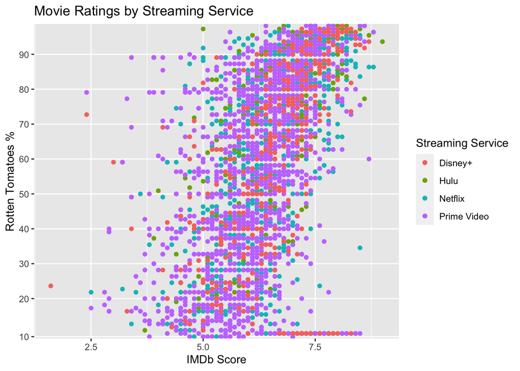

By visualizing the critical ratings against each other in this manner, we can see that these groups rate films in a similar way, but these rating systems are not the same. In order to find out which rating we as the consumer trust more, we need to understand the factors that lend to these rankings. Further, after grouping these points by streaming service, it is difficult to determine if any streaming service has an objectively better movie selection. It is therefore up to the consumer to place themselves within these rating systems and decide for themselves what they care about and which streaming service is best catered to their needs.

# Results

The results of this analysis first attempt to find the streaming service with the best selection of movies, with the quality of movies measured by the IMDb rating system. This portion of the investigation is carried out by completing an Analysis of Covariance, which is able to create regression coefficients associated with the impact of availability on each streaming service on a movie’s IMDb rating. Then, Lasso Regression and Random Forest Regression are used to attempt to predict IMDb ratings of movies from the other available characteristics. These predictive modelling techniques are useful to determine which factors are most impactful on a movie’s critical rating and how standardized the rating system is. These two insights can then determine how much a consumer trusts IMDb, and therefore how reliable the results of the Analysis of Covariance is.

## Analysis of Covariance

The first modeling technique is an Analysis of Covariance, designed to show the relationship between `IMDb` and the availability of movies on `Netflix`, `Hulu`, `Amazon Prime Video`, and `Disney+`.

Coefficients from Analyses of Variance

|  | Netflix | Hulu | Prime Video | Disney+ |
| --- | --- | --- | --- | --- |
| Intercept | 5.8080669 | 5.8890125 | 6.2708558 | 5.8833248 |
| Streaming Service Coefficient | 0.4448965 | 0.2491041 | -0.4999455 | 0.5580606 |

The table above shows all of the linear coefficients calculated from an Analysis of Variance between each of the streaming services and IMDb rating. These calculations were produced after initial linear models were generated and the significance of each of the potential variables was tested. All four of the streaming services proved to be significant. Therefore, the above table can give an indication of the influence that availability of a movie on each of the four streaming services has individually on IMDb rating. However, this is an incomplete picture of the potential relationships between streaming services and movie rating because most of the movies in the set were included on multiple streaming platforms. In order to account for interactions between these streaming services, an Analysis of Covariance was conducted, the results of which are shown in the table below.

Coefficients from Analysis of Covariance

|  | Coefficients |
| --- | --- |
| Intercept | 5.8794914 |
| Netflix | 0.3824440 |
| Hulu | 0.2778883 |
| Prime Video | -0.1260526 |
| Disney+ | 0.5559000 |

Our Analysis of Covariance resulted in the following coefficients and intercept. From these results, we can see that `Disney+` has the largest positive impact on `IMDb`, followed by `Netflix` and `Hulu`. `Amazon Prime Video` had the only negative impact. Pragmatically, this means that `Disney+` has the highest average critical rating, making it the best investment for a consumer wanting the highest rated selection of movies. It is worth noting that `Amazon Prime Video` has a significantly higher number of movies available through their subscription, which could explain the negative coefficient.

In order to be able to use the results of this model, we have to understand the factors that lead to an IMDb score. The rest of the analysis will attempt to use predictive modelling to predict IMDb score from the characteristics of movies. From this information, consumers will be able to decide if they align with the IMDb rating system.

## Prediction of IMDb Rating

### Random Forest Regression

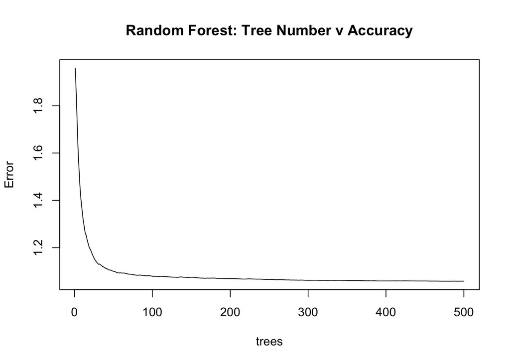

The graph above illustrates the error of predictions graphed against the number of trees used in generating that prediction. Random Forest Regression aims to find the most accurate model of prediction by generating and comparing a multitude of decision trees. The more trees added to the model, the more accurate it will be but the more overly complicated and over-fit it can become. The number of trees used in our prediction was generated to be close to the horizontal asymptote of this graph, such that the prediction was as accurate as possible but not overly complicated.

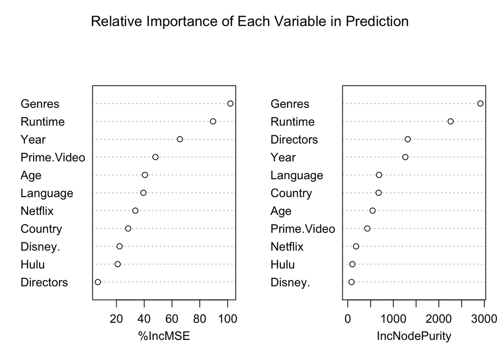

The plot above illustrates the relative importance of each variable, which was used in the determination of coefficients to provide the most accurate model. Focusing on the percentage increased in mean squared error, it’s clear to see that `Genres` has the highest variable importance, followed by `Runtime` and `Year`, resulting in higher predictive power in the analysis. Removing these variables of high importance generates significant loss of accuracy on the prediction results. On the other hand, looking at the table of increased node purity, we see some differences compared to percentage increase in mean square error, which is one of the results of measuring the node impurity. Splits of the data set based on each variable is biased towards variables with many classes, which also biases the importance measure. In our case, the bias results in different orders regarding the importance of variables. However, `Genres` and `Runtime` have the highest importance in both ways.

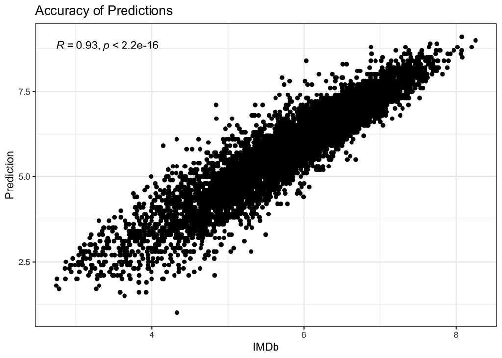

The figure above illustrates the accuracy of the Random Forest Predictions against the actual IMDb ratings for each title, as well as the R and p-values of the model. The shape of the points shows a positive correlation between the prediction and observed IMDb rating, roughly resembling a straight line which indicates a highly accurate model. This is reflected in the R value, the p-value, and the Root Mean Squared Error. These results indicate that the relative importance of each coefficient measured by Random Forest Regression is an accurate prediction of how IMDb is measured.

| Root Mean Squared Error |
| --- |
| 0.5805289 |

The Root Mean Squared Error indicates that Random Forest is a very accurate tool to test the relative importance of each coefficient in predicting IMDb score. The coefficients listed in order of importance by this model are `Genre`, `Runtime`, `Year`, `Prime.Video`, `Age`, `Language`, `Netflix`, `Country`, `Disney`, `Hulu`, and `Directors`.

### Lasso Regression

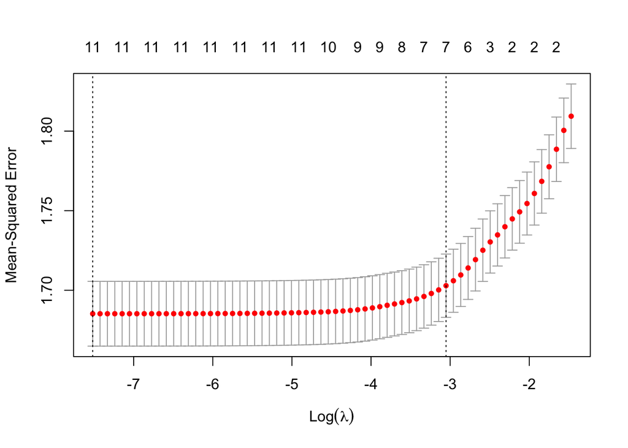

The plot above shows, with error margins, the Mean Squared Error of each Regression model against the Lambda used in creating that prediction. The goal of Lasso Regression is to find and use the Lambda value that minimizes error without making the model over-fit to the data. The best lambda calculated by the model and used in our analysis is the one which minimizes error, which appears to be along the horizontal anymptote.

| Variable | Coefficients |
| --- | --- |
| Intercept | 17.2161847 |
| Year | -0.0059313 |
| Age | -0.0162857 |
| Netflix | 0.3305844 |
| Hulu | 0.2693370 |
| Amazon Prime Video | -0.2146732 |
| Disney + | 0.6558734 |
| Directors | 0.0000045 |
| Genres | 0.0003410 |
| Country | -0.0000940 |
| Language | 0.0007146 |
| Run Time | 0.0024547 |

Certain values in this are seemingly illogical in the scope of the analysis. For example, the intercept of the line is higher than the maximum IMDb score of 10. However, this value is explained by the Year variable, for which there is a minimum non-zero value (minimum Year is 1939). The unscaled year variable, and resulting intercept, are valuable to this analysis because it shows how much IMDb rating changes on average by year.

|  | Test Set | Train Set |
| --- | --- | --- |
| RMSE | 1.2968176 | 1.3371949 |
| R square | 0.0705183 | 0.0204439 |

In the calculation of Root Mean Squared Error and R-squared values, it is worth noting that the R-squared value for both the training set and the testing set is close to 0. This means that Lasso Regression was able to quantify the relationship between each variable and the IMDb rating, but these coefficients were not able to accurately predict IMDb ratings, and that the relative importance calculated by the Random Forest Regression may be more appropriate for comparison. In future analysis, in order for Lasso Regression to be more accurate as a predictive tool, the year variable should either be scaled or adjusted (for example by subtracting the minimum value from each of the values).

## Explanation of Results

The Root Mean Squared Error for each of the models we developed were low, but the R-square values for the Lasso Regression models we developed were close to zero. This indicates that while we are able to claim the relative importance of movie characteristics for each rating system within our set, the values of the coefficients we found for each model were poor predictive tools for predicting critical ratings of other films. However, we can determine that Disney+ has the highest positive correlation with highly rated movies, meaning that this streaming service may be a better investment for consumers who trust IMDb.

# Conclusion

In the future, other statisticians can build upon this work by identifying and testing more specific variables such as how actors, franchise, production company, etc affect average critical ratings. There is also room to further investigate which demographics use which streaming services the most for the purpose of better preparing companies to reach their target audience more efficiently. If they can reach more specific demographics, companies can tailor their content in a fashion that allows for more personalized content on the consumer end. This kind of work could potentially be incorporated in future algorithms for predicting “for you” tabs on the front pages of streaming platforms. In order to complete any of this research, however, we would need access to more specific data sets regarding revenue and actor presence in content. Although difficult, such research would be to create a more harmonious relationship between consumers and producers alike.